# Introdução aos gráficos

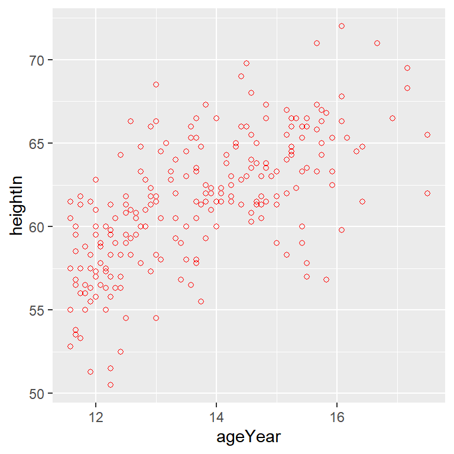

```r
p + geom_point(shape = 1, colour = "red")
```

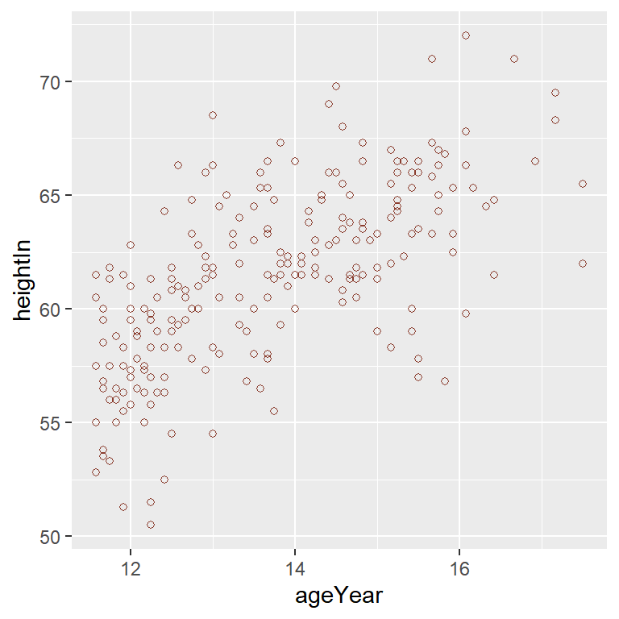

```r
p + geom_point(shape = 1, colour = "coral4")
```

Podemos também diferenciar a color da linha do ponto e do preenchimento do ponto. No entanto, a alteração do preenchimento só é possivel para os pontos com shape entre 21–25

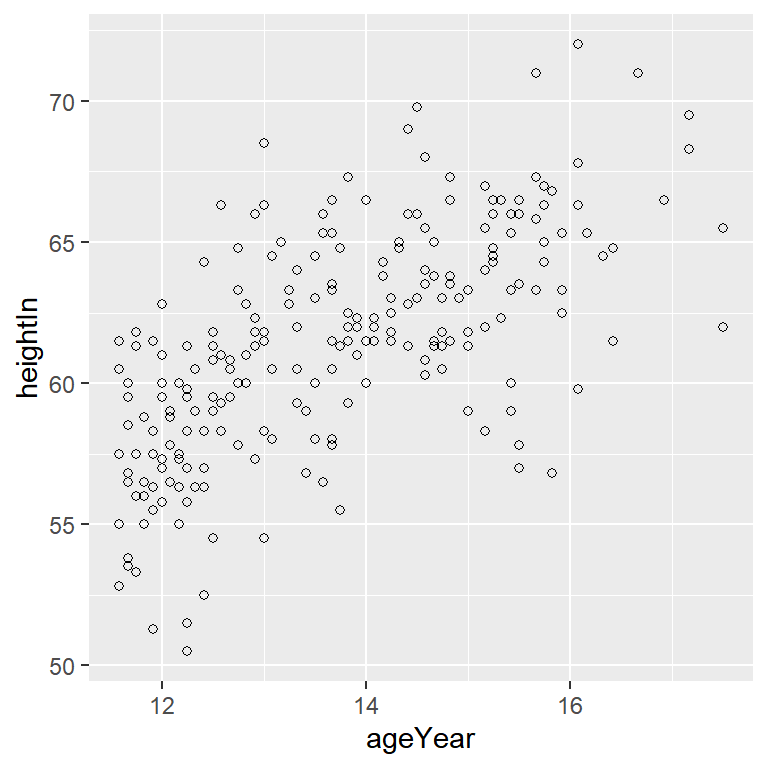

```r
p + geom_point(shape = 1, colour = "black", fill = "red")
```

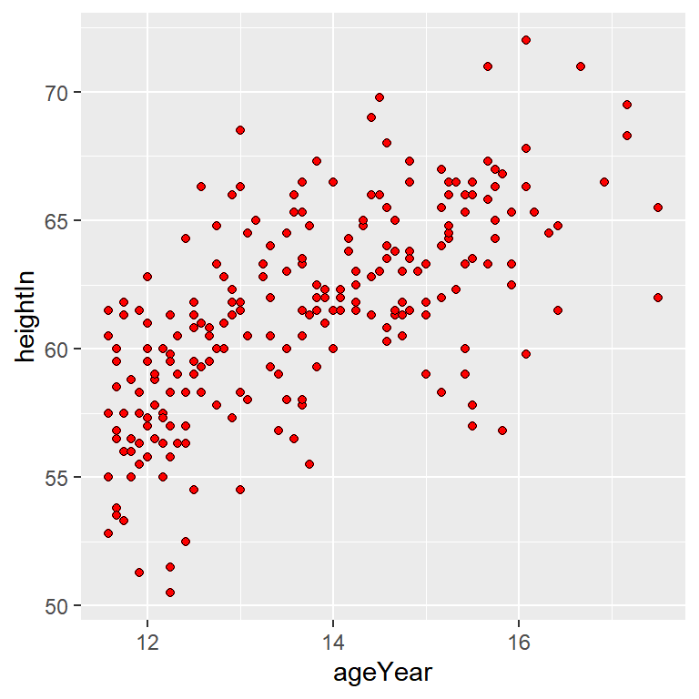

```r
p + geom_point(shape = 21, colour = "black", fill = "red")
```

Por fim, podemos adicionar todos estes elementos simultaneamente

[figure not shown]

```r
p + geom_point(shape = 5, size = 3, color = 4)
```

Aprendemos que para definirmos elementos visuais de um gráfico, adicionamos comandos dentro da função geom_(). Porém, nem todos os gráficos suportam os mesmo comandos. Por exemplo, não é possível alterar o formato do ponto em um gráfico de linhas.

Vamos ver alguns elementos visuais para outros tipos de gráficos. Em graficos de linha, podemos mudar o tipo de linha (linetype), a largura (size) e a cor(color).

```r
BOD
```

```
##   Time demand
## 1    1    8.3
## 2    2   10.3
## 3    3   19.0
## 4    4   16.0
## 5    5   15.6
## 6    7   19.8
```

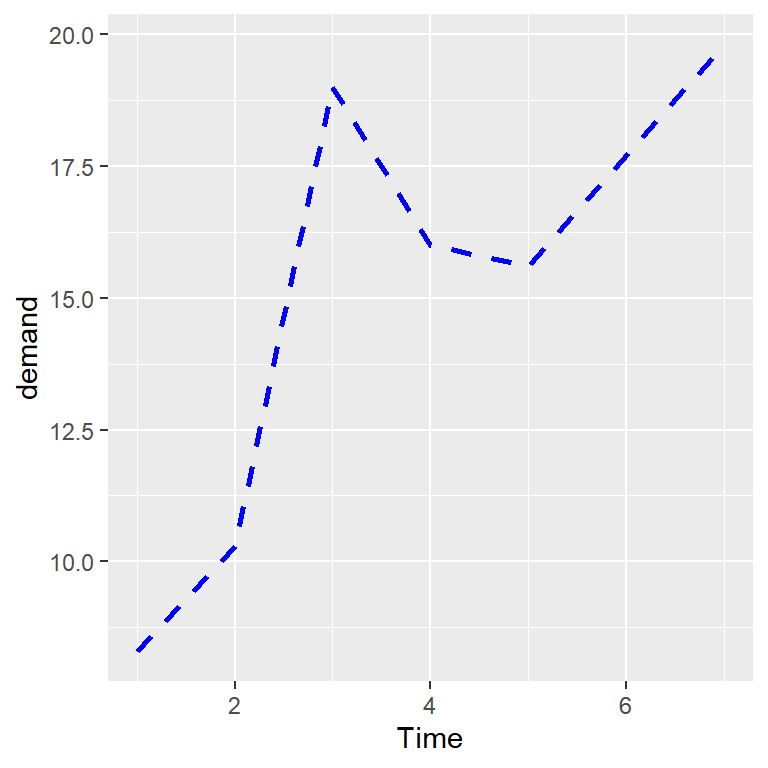

```r
p <- ggplot(BOD, aes(x = Time, y = demand))

p + geom_line(linetype = "dashed", size = 1, color = "blue")
```

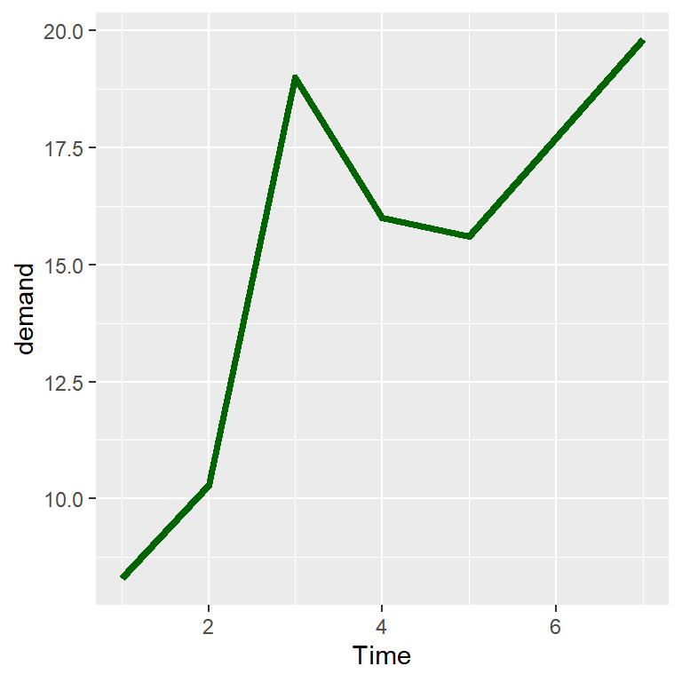

```r
p + geom_line(color = "darkgreen", size = 1.5)
```

Um argumento bastante interessante é a transparência (alpha), que pode ser fundamental para termos uma melhor interpretação e visualização do gráfico. Veja, por exemplo, a diferença entre estes gráficos de pontos.

```r
diamonds
```

```
## # A tibble: 53,940 × 10
##    carat cut       color clarity depth table price     x     y     z
##    <dbl> <ord>     <ord> <ord>   <dbl> <dbl> <int> <dbl> <dbl> <dbl>
##  1  0.23 Ideal     E     SI2      61.5    55   326  3.95  3.98  2.43
##  2  0.21 Premium   E     SI1      59.8    61   326  3.89  3.84  2.31
##  3  0.23 Good      E     VS1      56.9    65   327  4.05  4.07  2.31
##  4  0.29 Premium   I     VS2      62.4    58   334  4.2   4.23  2.63
##  5  0.31 Good      J     SI2      63.3    58   335  4.34  4.35  2.75
##  6  0.24 Very Good J     VVS2     62.8    57   336  3.94  3.96  2.48
##  7  0.24 Very Good I     VVS1     62.3    57   336  3.95  3.98  2.47
##  8  0.26 Very Good H     SI1      61.9    55   337  4.07  4.11  2.53
##  9  0.22 Fair      E     VS2      65.1    61   337  3.87  3.78  2.49
## 10  0.23 Very Good H     VS1      59.4    61   338  4     4.05  2.39
## # … with 53,930 more rows
```

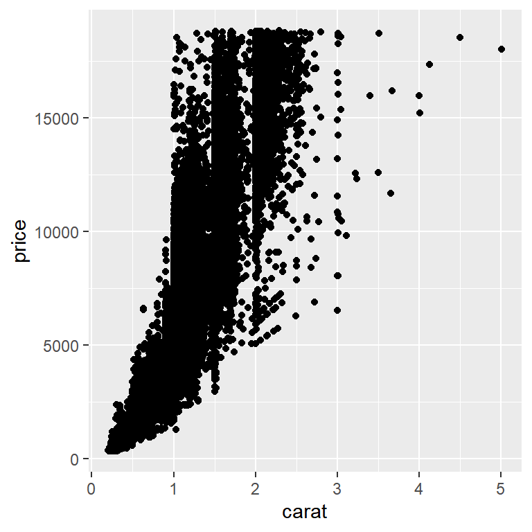

```r
p <- ggplot(diamonds, aes(x = carat, y = price))

p + geom_point()
```

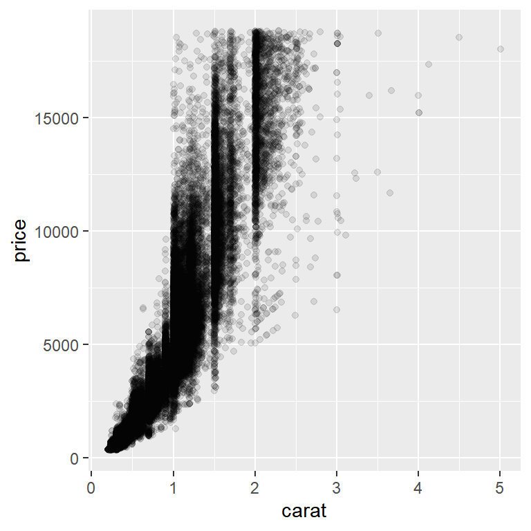

```r
p + geom_point(alpha = .1)
```

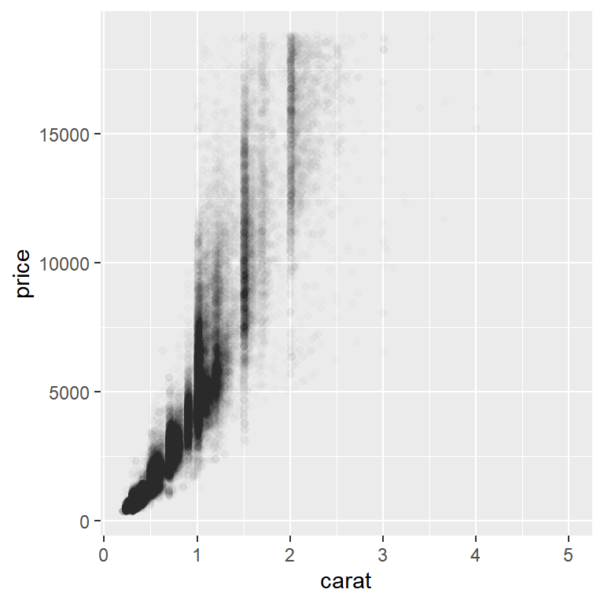

```r
p + geom_point(alpha = .01)
```

Similarmente, podemos usar o argumento alpha para os gráficos de linha

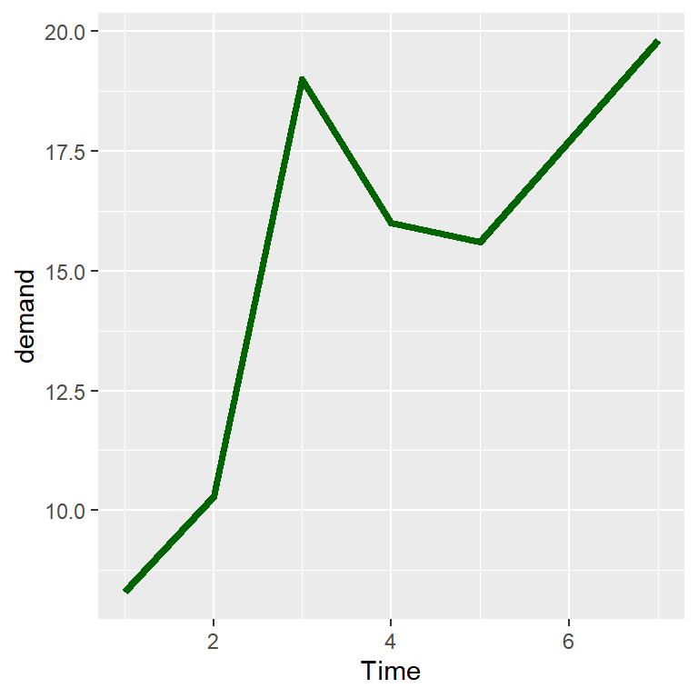

```r
p <- ggplot(BOD, aes(x = Time, y = demand))

p + geom_line(color = "darkgreen", size = 1.5)
```

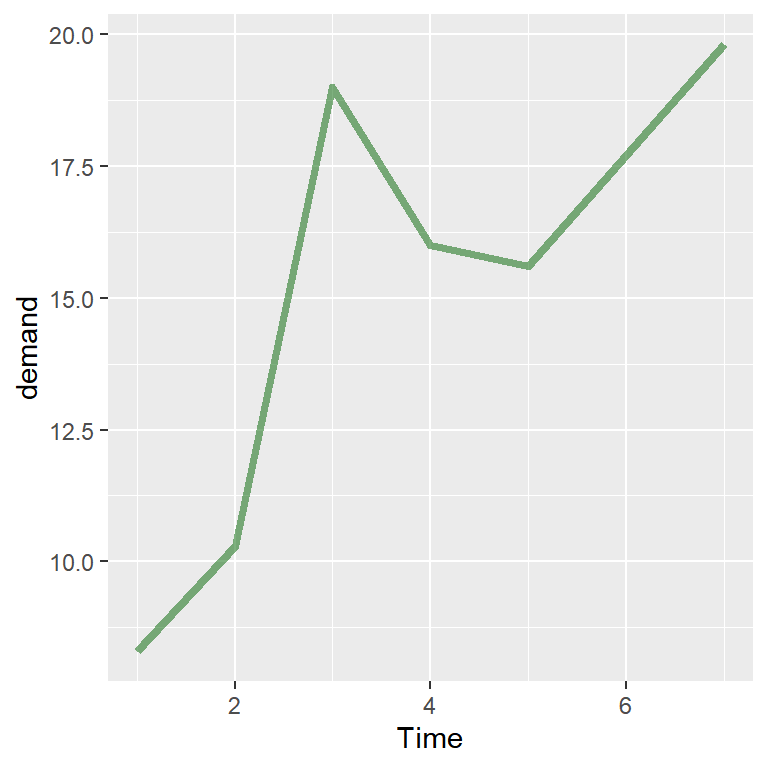

```r
p + geom_line(color = "darkgreen", size = 1.5, alpha = 0.5)
```

Para gráficos de barras, os argumentos relacionados aos elementos visuais são similares aos outros gráficos

```r
pg_mean
```

```
##   group weight
## 1  ctrl  5.032
## 2  trt1  4.661
## 3  trt2  5.526
```

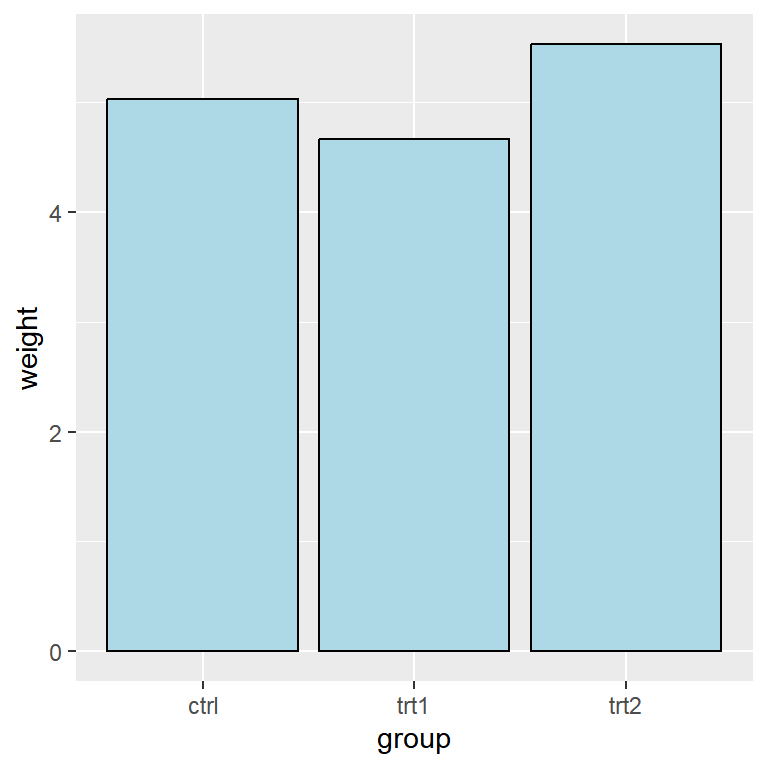

```r
p <- ggplot(pg_mean, aes(x = group, y = weight))

p + geom_col(color = "black", fill = "lightblue")
```

# Exercícios

3. Busque no seu script os códigos utilizados nos gráficos criados no exercício anterior. Adicione elementos visuais de cor, tamanho, formato e preenchimento, conforme vimos na aula.